# 描述性统计

# 数据准备

```r
rm(list = ls())
nba = read.csv("NBA.csv")#引入数据源
nba#显示所以数据
```

```
##                     球员姓名     位置 身高 体重 年龄 球龄 上场次数
## 1                斯蒂芬-库里 得分后卫 1.91   86   29    7       79
## 2              勒布朗-詹姆斯   大前锋 2.03  113   32   13       74
## 3              保罗-米尔萨普     中锋 2.03  112   32   10       69
## 4                戈登-海沃德   小前锋 2.03  103   27    6       73
## 5              布雷克-格里芬     中锋 2.08  114   28    6       61
## 6                  凯尔-洛里 控球后卫 1.85   89   31   10       60
## 7          拉塞尔-维斯布鲁克 控球后卫 1.91   91   28    8       81
## 8                  迈克-康利 控球后卫 1.85   79   29    9       69
## 9                詹姆斯-哈登 得分后卫 1.96  100   28    7       81
## 10             德玛尔-德罗赞   小前锋 2.01   99   28    7       74
## 11               艾尔-霍弗德     中锋 2.08  111   31    9       68
## 12             卡梅隆-安东尼   大前锋 2.03  109   33   13       74
## 13             达米安-利拉德 控球后卫 1.91   88   27    4       75
## 14                 朱-霍勒迪 控球后卫 1.93   93   27    7       67
```

[output cut: 781 more lines]

```r
par(family = 'STKaiti')#转换中文码
```

## 单变量

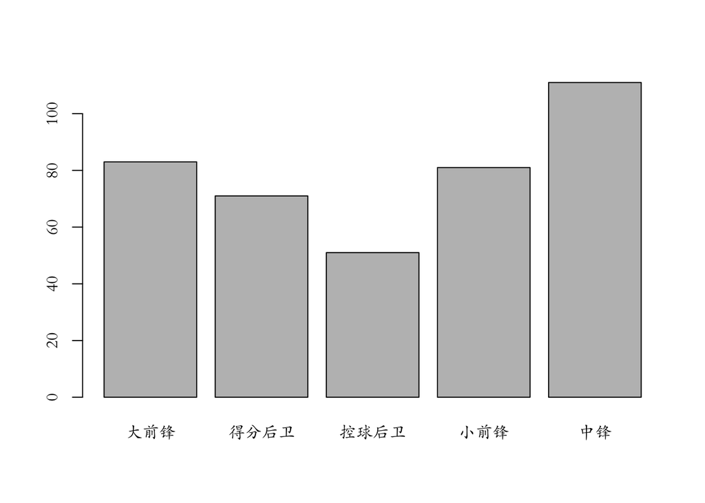

```r
par(family = 'STKaiti')
## 定性变量--柱状图 ##
a = table(nba$位置)#统计NBA个位置球员人数
barplot(a, names.arg = names(a))#画出柱状图
```

总体样本个数为397个，其中样本量最多的位置是中锋，有111个样本数据。其次是大前锋球员的样本量，有83个。小前锋样本量接近大前锋样本量，有81个。得分后卫和控球后卫的样本量较小，其中得分后卫有71个样本，控球后卫有51个样本。

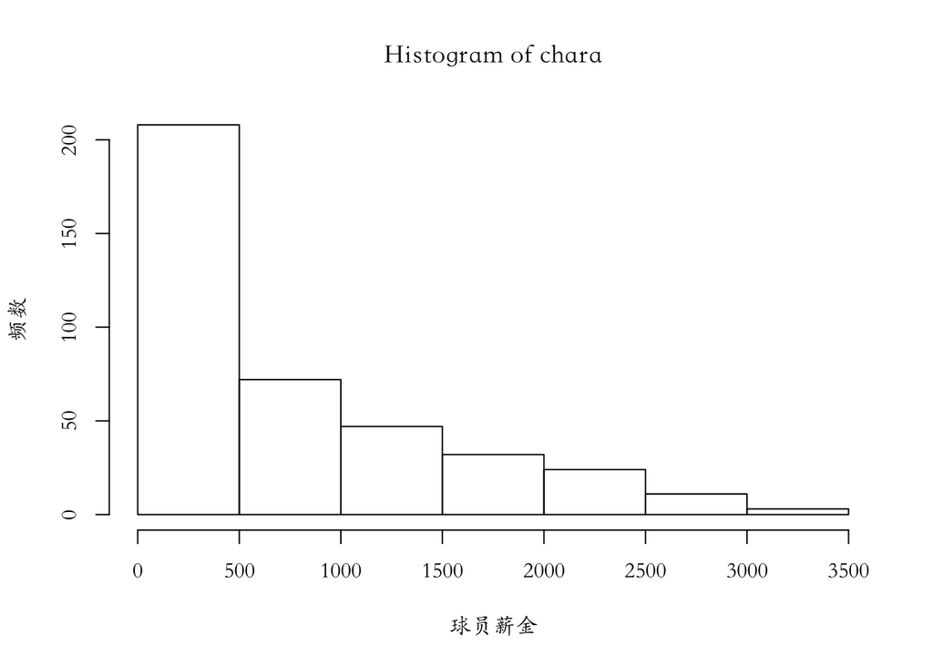

```r
## 定量变量--直方图 ##
par(family = 'STKaiti')
chara = sort(nba$球员薪金)[1:1500]
hist(chara, breaks = 10, xlab = "球员薪金", ylab = "频数")
```

薪金在0到500万美金的有208人，在500-1000万美金的有72人，在1000-1500万美金的有47人，在1500-2000万美金的有32人，在2000-25000万美金的有24人，在2500-3000万美金的有11人，在3000万美金以上仅有3人，分别是斯蒂芬-库里、勒布朗-詹姆斯、保罗-米尔萨普。说明NBA球员的薪金存在较大的差异，明星球员的薪金均值在782.4万美元，但是有245位球员的薪金在均值之下。

## 多变量

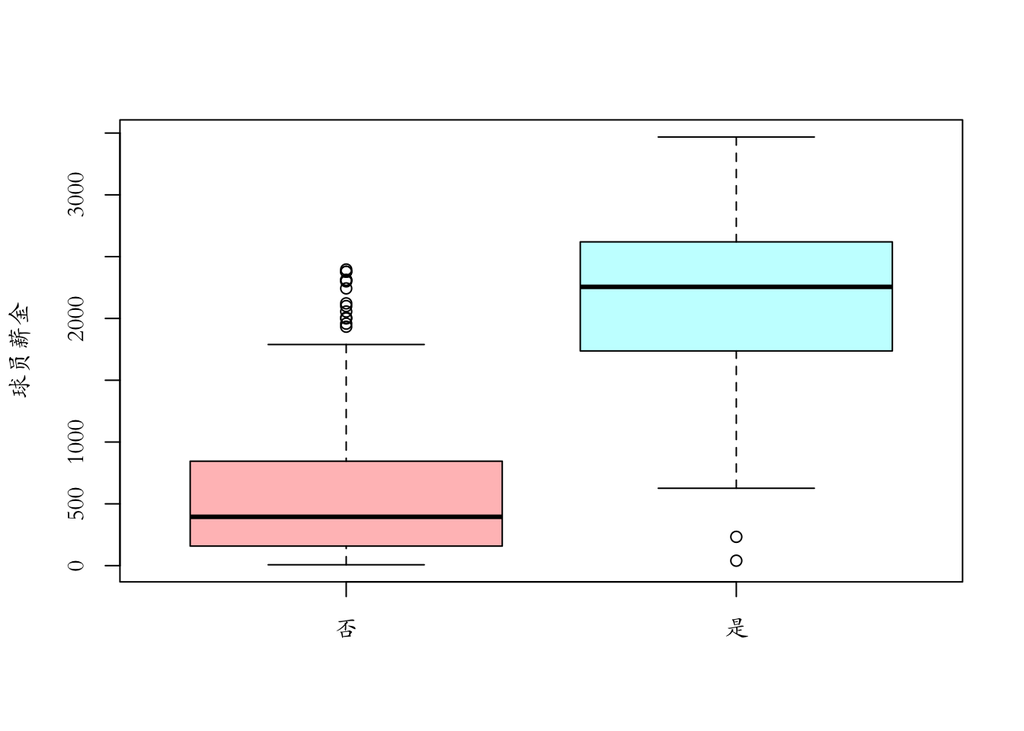

```r
par(family = 'STKaiti')
## 定性与定量变量--分组箱线图 ##
boxplot(nba$球员薪金~是否入选过全明星, data = nba, col = rainbow(2, alpha = 0.3), ylab = "球员薪金")
```

如箱线图所示，有349名球员没有入选过全明星，48位球员入选过全明星。其中未入选球员的薪金中位数对数比入选球员的薪金中位数低，说明入选过全明星的球员比未入选过全明星的球员更受球队的青睐，球队交易金额更高。同时，通过箱线图还发现，入选过全明星的球员薪金除极个别球员外均比75%的未入选全明星的球员薪金高，且入选过全明星的球员薪金中位数基本与未入选过全明星的球员薪金极大值持平。因此，对于球员而言，是否入选全明星较大程度影响其薪金的议价能力。而个别入选全明星薪金却异常的球员可能是因为合同签订时未入选全明星但入选全明星后合同约定薪金仍有效，这些球员在合同到期后薪金水平可预期地会大幅上涨。

```r
# 定量与定量之间--散点图矩阵
par(family = 'STKaiti')
student = read.csv('student.csv')
head(student)
```

```
##   Y1  Y2 Y3 Y4 Y5 Y6
## 1 65  61 72 84 81 79
## 2 77  77 76 64 70 55
## 3 67  63 49 65 67 57
## 4 78  84 75 62 71 64
## 5 66  71 67 52 65 57
## 6 83 100 79 41 67 50
```

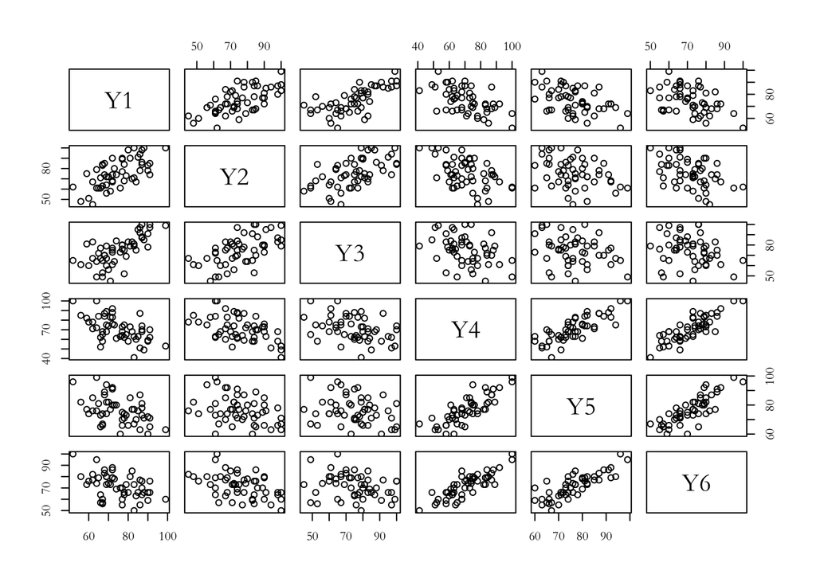

```r
pairs(student)
```

样本是某学生群体的成绩，样本容量为52,变量包括Y1、Y2、Y3、Y4、Y5、Y6六个学科的成绩。

由散点图矩阵可知，学科成绩Y1、Y2、Y3彼此之间存在明显的正线性相关关系；而学科成绩Y4、Y5、Y6彼此之间也存在明显的正线性相关关系。且Y1、Y2、Y3与Y4、Y5、Y6之间，两两不存在明显的线性相关关系。说明影响学生Y1、Y2、Y3学科成绩的主因素和影响Y1、Y2、Y3学科成绩的主因素不是同一种学生因素。即存在两种知识水平或能力对Y1、Y2、Y3与Y4、Y5、Y6起到较大的影响。